# Analysis of impact of weather events on public health and economic damage in the US

Davyd

May, 2018

## Health and Economic Impact of Weather Events in the US

Storms and other severe weather events can cause both public health and economic problems for communities and municipalities. Many severe events can result in fatalities, injuries, and property damage, and preventing such outcomes to the extent possible is a key concern.

This project involves exploring the U.S. National Oceanic and Atmospheric Administration’s (NOAA) storm database. This database tracks characteristics of major storms and weather events in the United States, including when and where they occur, as well as estimates of any fatalities, injuries, and property damage.

## Data Processing

```r
rawData = read.csv('repdata_data_StormData.csv', stringsAsFactors=FALSE)
names(rawData)
```

```
##  [1] "STATE__"    "BGN_DATE"   "BGN_TIME"   "TIME_ZONE"  "COUNTY"
##  [6] "COUNTYNAME" "STATE"      "EVTYPE"     "BGN_RANGE"  "BGN_AZI"
## [11] "BGN_LOCATI" "END_DATE"   "END_TIME"   "COUNTY_END" "COUNTYENDN"
## [16] "END_RANGE"  "END_AZI"    "END_LOCATI" "LENGTH"     "WIDTH"
## [21] "F"          "MAG"        "FATALITIES" "INJURIES"   "PROPDMG"
## [26] "PROPDMGEXP" "CROPDMG"    "CROPDMGEXP" "WFO"        "STATEOFFIC"
## [31] "ZONENAMES"  "LATITUDE"   "LONGITUDE"  "LATITUDE_E" "LONGITUDE_"
## [36] "REMARKS"    "REFNUM"
```

```r
dim(rawData)
```

```
## [1] 902297     37
```

Among all these dimensions, we will only select 8 variables that are related to this analysis, which are:

- STATE
- EVTYPE
- FATALITIES
- INJURIES
- PROPDMG
- PROPDMGEXP
- CROPDMG
- CROPDMGEXP

```r
variName<- c("STATE", "EVTYPE", "FATALITIES", "INJURIES", "PROPDMG", "PROPDMGEXP","CROPDMG", "CROPDMGEXP")
data <-rawData[variName]
dim(data)
```

```
## [1] 902297      8
```

```r
head(data)
```

```
##   STATE  EVTYPE FATALITIES INJURIES PROPDMG PROPDMGEXP CROPDMG CROPDMGEXP
## 1    AL TORNADO          0       15    25.0          K       0
## 2    AL TORNADO          0        0     2.5          K       0
## 3    AL TORNADO          0        2    25.0          K       0
## 4    AL TORNADO          0        2     2.5          K       0
## 5    AL TORNADO          0        2     2.5          K       0
## 6    AL TORNADO          0        6     2.5          K       0
```

Look at missing values

```r
sum(is.na(data))
```

```
## [1] 0
```

Here we calculate the type of events that would cause large number of fatalities and injuries from 1950 to November 2011. We aggregate the data using sum first then rank by decreasing order.

```r
fatal <- aggregate(FATALITIES ~ EVTYPE, data = data, FUN = sum)
injury <- aggregate(INJURIES ~ EVTYPE, data = data, FUN = sum)
fatalOrder <- fatal[order(fatal$FATALITIES, decreasing = TRUE), ]
injuryOrder <- injury[order(injury$INJURIES, decreasing = TRUE), ]
```

Let’s look at property damage and crop damage unique data first.

```r
unique(data$PROPDMGEXP)
```

```
##  [1] "K" "M" ""  "B" "m" "+" "0" "5" "6" "?" "4" "2" "3" "h" "7" "H" "-"
## [18] "1" "8"
```

```r
unique(data$CROPDMGEXP)
```

```
## [1] ""  "M" "K" "m" "B" "?" "0" "k" "2"
```

We can see that there are both numerical and alphbetical characters to represent significant digits. For example, “8” would be 10^8 and “K” or “k” would be thousands. So we want to make the number format consistent first.

```r
symbol <- c("","+","-","?",0:9,"h","H","k","K","m","M","b","B")
factor <- c(rep(0,4),0:9,2,2,3,3,6,6,9,9)
multipler <-data.frame(symbol,factor)
```

Here we calculate the type of events that would cause large number of property and crop damage from 1950 to November 2011. We aggregate the data using sum first then rank by decreasing order.

```r
data$PROPDMGVAL <-data$PROPDMG* 10^multipler[match(data$PROPDMGEXP,multipler$symbol),2]
data$CROPDMGVAL <-data$CROPDMG* 10^multipler[match(data$CROPDMGEXP,multipler$symbol),2]

propdmg <- aggregate(PROPDMGVAL ~EVTYPE,data=data, FUN = sum)
cropdmg <- aggregate(CROPDMGVAL ~EVTYPE,data=data, FUN= sum)

propOrder <-propdmg[order(propdmg$PROPDMGVAL,decreasing=TRUE),]
cropOrder <-cropdmg[order(cropdmg$CROPDMGVAL,decreasing=TRUE),]
```

## Results

**Harmful events to human healths: fatalities & injuries**

Now we draw two figures with top 10 fatality and injury event types separately.

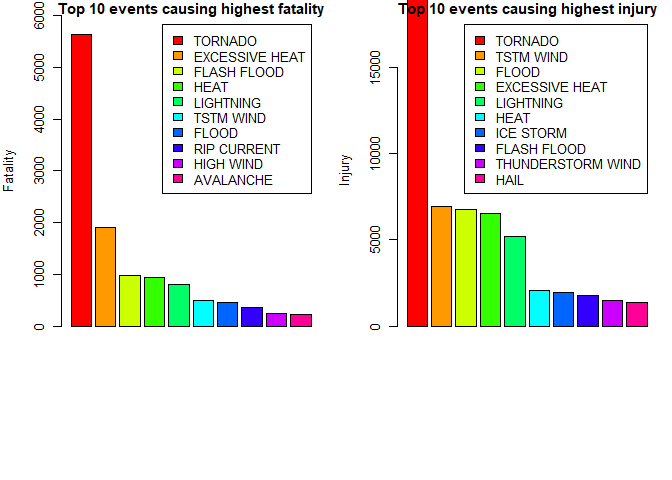

```r
par(mfrow=c(1,2), mar= c(10,4,1,1), mgp=c(3,1,0), cex=0.8)
barplot(fatalOrder[1:10,2], col = rainbow(10), legend.text=fatalOrder[1:10,1],ylim=c(0,6000),ylab="Fatality", main="Top 10 events causing highest fatality")
barplot(injuryOrder[1:10,2], col = rainbow(10), legend.text=injuryOrder[1:10,1],ylim=c(0,18000),ylab="Injury", main="Top 10 events causing highest injury")
```

**Harmful events to economic damages: property & crop damage**

Now we draw two figures with top 10 property and crop damage types separately.

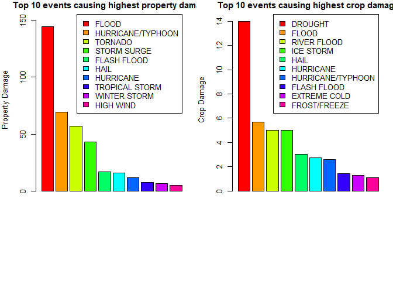

```r
par(mfrow=c(1,2), mar= c(10,4,1,1), mgp=c(3,1,0), cex=0.8)
barplot(propOrder[1:10,2]/10^9, col = rainbow(10), legend.text=propOrder[1:10,1],ylim=c(0,160),ylab="Property Damage", main="Top 10 events causing highest property damage")
barplot(cropOrder[1:10,2]/10^9, col = rainbow(10), legend.text=cropOrder[1:10,1],ylim=c(0,15),ylab="Crop Damage", main="Top 10 events causing highest crop damage")
```

The plot showed that flood, hirricane/typhoon and tornado hit the properties the hardest while drought and different types of flood hit the crop the hardest.